# Analiza jakości powietrza

Michał Ziemianek & Miłosz Jeżyna

21 listopad, 2021

# 1. Cel projektu

Projekt ma na celu analizę pomiarów powietrza w wybranych stacjach, a następnie ocenę jakości mierzonego powietrza. Ponadto, dodatkowym celem jest sprawdzenie skutecznosci metody automatycznej w stosunku do metody manualnej. Do wykonania projektu został użyty pakiet `giosimport`, którego zadaniem jest pobieranie i wczytywanie danych z portalu jakości powietrza GIOŚ.

# 2. Przygotowanie danych

## 2.1 Wczytanie pakietów

Żeby przygotować dane, które będziemy analizować, musieliśmy najpierw zainstalować, a następnie wczytać niezbędne narzędzia m.in.: pakiet `devtools`, a także inne.

```r
if(!require(devtools)) {install.packages("devtools")
require(devtools)}

library(giosimport)
library(dplyr)
library(purrr)
library(ggplot2)
library(stringr)
library(tidyr)
library(leaflet)
library(openxlsx)
library(janitor)
library(openair)
library(Rcpp)
library(DT)
```

## 2.2 Pobranie danych

Metadane dotyczące stacji oraz stanowisk pobieramy ze strony [Głównego Inspektoratu Ochrony Środowiska](http://powietrze.gios.gov.pl/pjp/current), przy pomocy funkcji `gios_metadane`, która zawiera się w pakiecie `giosimport`. Oprócz tego pobieramy również statystyki dotyczące poszczególnych substancji w atmosferze.

```r
stacje <- gios_metadane(type = "stacje",
                      download = F,
                      path = kat_dost,
                      mode = "wb")

stanowiska <- gios_metadane(type = "stanowiska",
                            download = F,
                            path = kat_dost,
                            mode = "wb")

statystyki <- gios_metadane(type = "statystyki",
                            download = F,
                            path = kat_dost,
                            mode = "wb")
```

Przy użyciu funkcji `gios_download` pobieramy archiwalne pliki z banku danych pomiarów portalu [GIOŚ](http://powietrze.gios.gov.pl/pjp/archives). Wykorzystana funkcja umożliwia również natychmiastowe rozpakowanie plików do wskazanej lokalizacji.

```r
pliki_2020 <- gios_download(url = zrodlo[21,1],
                            rok = zrodlo[21,2],
                            path = kat_dost,
                            mode = "wb")
```

## 2.3 Selekcja danych

### 2.3.1 Wybranie odpowiednich stacji

Następnie wybieramy tylko aktywne stacje, oraz przy pomocy funkcji `gios_vis` wizualizujemy ich położenie, na mapie.

```r
gios_vis(data = stacje %>% filter(is.na(data.zamkniecia)))
```

[interactive chart not shown]

Wśród stanowisk, wybieramy tylko takie stacje, na których poziom pyłu zawieszonego PM10 mierzony jest zarówno metodą automatyczną (co 1h), jak i metodą manualną (co 24h).

```r
identyfikacja <- stanowiska %>%
  filter(`wskaznik.-.kod` == "PM10") %>%
  filter(typ.pomiaru == c("automatyczny", "manualny")) %>%
  pull(kod.stacji)
```

Teraz możemy zwizualizować stacje, które spełniają powyższe warunki.

```r
gios_vis(data = stacje %>%
           filter(is.na(data.zamkniecia),
                  kod.stacji %in% identyfikacja))
```

[interactive chart not shown]

Zobaczmy teraz średnie roczne stężenie pyłu zawieszonego PM10 mierzonego metodą manualną, dla stacji znajdujących się na obszarze Aglomeracji Górnośląskiej - tutaj mieszczą się stacje (`SlKatoKossut` i `SlDabro1000L`), które wybraliśmy do dalszej analizy jakości powietrza. Czerwona linia pokazuje maksymalne dopuszczalne stężenie pyłu PM10.

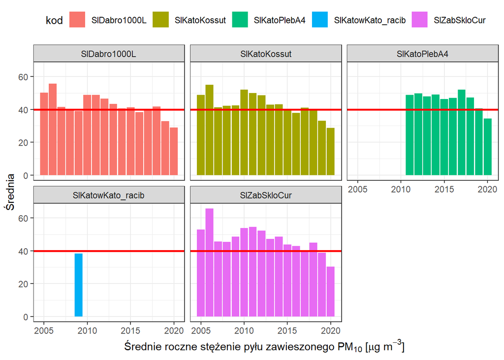

```r
statystyki[["PM10"]] %>%
  filter(Czas.uśredniania == "24g",
         Nazwa.strefy == "Aglomeracja Górnośląska") %>%
  ggplot(., aes(x = Rok,
                y = Średnia,
                fill = Kod.stacji),
         color = "black") +
  geom_col(position = position_dodge2(0.2)) +
  geom_hline(yintercept = 40, color = 'red', size = 1) +
  facet_wrap(~Kod.stacji) +
  theme_bw() +
  theme(legend.position = "top",
        legend.direction = "horizontal") +
  labs(x = openair::quickText("Średnie roczne stężenie pyłu zawieszonego PM10 [ug/m3]"),
       fill = "kod")
```

Możemy zauważyć, że w większości lat, na przedstawionych stacjach średnioroczny poziom stężenia pyłu zawieszonego PM10 przekracza maksymalne dopuszczalne stężenie , opisane w normie prawnej.

### 2.3.2 Wczytanie i selekcja danych pomiarowych

Za pomocą funkcji `gios_read` wczytujemy dane pomiarowe z pobranej bazy danych, dotyczące substancji mierzonych metodami manualną i automatyczną.

```r
#PM10:
#manualne:
pm10_24h_2020 <- gios_read(nazwa = "2020_PM10_24g.xlsx",
                       czas_mu = "24g",
                       path = kat_dost)

#automatyczne
pm10_1h_2020 <- gios_read(nazwa = "2020_PM10_1g.xlsx",
                           czas_mu = "1g",
                           path = kat_dost)

#dwutlenek siarki - SO2:
so2_1h_2020 <- gios_read(nazwa = "2020_SO2_1g.xlsx",
                         czas_mu = "1g",
                         path = kat_dost)

#tlenek azotu - NO:
no_1h_2020 <- gios_read(nazwa = "2020_NO_1g.xlsx",
                        czas_mu = "1g",
                        path = kat_dost)

#dwutlenek azotu - NO2:
no2_1h_2020 <- gios_read(nazwa = "2020_NO2_1g.xlsx",
                         czas_mu = "1g",
                         path = kat_dost)

#Ozon - O3:
o3_1h_2020 <- gios_read(nazwa = "2020_O3_1g.xlsx",
                        czas_mu = "1g",
                        path = kat_dost)

#PM2.5:
#automatyczne:
pm25_1h_2020 <- gios_read(nazwa = "2020_PM2.5_1g.xlsx",
                          czas_mu = "1g",
                          path = kat_dost)

#manualne:
pm25_24h_2020 <- gios_read(nazwa = "2020_PM2.5_24g.xlsx",
                           czas_mu = "24g",
                           path = kat_dost)

#ołów w PM10 - Pb(PM10):
pb_pm10_24h_2020 <- gios_read(nazwa = "2020_Pb(PM10)_24g.xlsx",
                              czas_mu = "24g",
                              path = kat_dost)

#Nikiel w PM10 - Ni(PM10):
ni_pm10_24h_2020 <- gios_read(nazwa = "2020_Ni(PM10)_24g.xlsx",
                              czas_mu = "24g",
                              path = kat_dost)

#Kadm w PM10 - Cd(PM10):
cd_pm10_24h_2020 <- gios_read(nazwa = "2020_Cd(PM10)_24g.xlsx",
                              czas_mu = "24g",
                              path = kat_dost)

#Arsen w PM10 - As(PM10):
as_pm10_24h_2020 <- gios_read(nazwa = "2020_As(PM10)_24g.xlsx",
                              czas_mu = "24g",
                              path = kat_dost)

#Benzo(a)piren w PM10 - BaP(PM10):
bap_pm10_24h_2020 <- gios_read(nazwa = "2020_BaP(PM10)_24g.xlsx",
                              czas_mu = "24g",
                              path = kat_dost)
```

Zobaczmy, jak wyglądają pobrane pliki, na przykładzie pomiarów manualnych stężeń PM10.

```r
head(pm10_24h_2020)
```

| kod | sub | date | obs |
| --- | --- | --- | --- |
| DsGlogWiStwo | PM10 | 2020-01-01 | 26.99 |
| DsGlogWiStwo | PM10 | 2020-01-02 | 63.22 |
| DsGlogWiStwo | PM10 | 2020-01-03 | 20.03 |
| DsGlogWiStwo | PM10 | 2020-01-04 | 12.03 |
| DsGlogWiStwo | PM10 | 2020-01-05 | 18.48 |
| DsGlogWiStwo | PM10 | 2020-01-06 | 21.62 |

Teraz wybieramy tylko interesujące nas dane dla wybranych przez nas stacji.

```r
#teraz wybieramy tylko dane z 2020 dla naszych wybranych stacji:
#PM10
pm10_1h_2020_Kato <-  pm10_1h_2020 %>%  filter(kod == "SlKatoKossut")
pm10_24h_2020_Kato <- pm10_24h_2020 %>% filter(kod == "SlKatoKossut")

pm10_1h_2020_Dabro <-  pm10_1h_2020 %>%  filter(kod == "SlDabro1000L")
pm10_24h_2020_Dabro <- pm10_24h_2020 %>% filter(kod == "SlDabro1000L")

#SO2
so2_1h_2020_Kato <- so2_1h_2020 %>% filter(kod == "SlKatoKossut")

so2_1h_2020_Dabro <- so2_1h_2020 %>% filter(kod == "SlDabro1000L")

#NO
no_1h_2020_Kato <- no_1h_2020 %>% filter(kod == "SlKatoKossut")

no_1h_2020_Dabro <- no_1h_2020 %>% filter(kod == "SlDabro1000L")

#NO2
no2_1h_2020_Kato <- no2_1h_2020 %>% filter(kod == "SlKatoKossut")

no2_1h_2020_Dabro <- no2_1h_2020 %>% filter(kod == "SlDabro1000L")

#O3
o3_1h_2020_Kato <- o3_1h_2020 %>% filter(kod == "SlKatoKossut")

o3_1h_2020_Dabro <- o3_1h_2020 %>% filter(kod == "SlDabro1000L")

#PM2.5
pm25_1h_2020_Kato <-  pm25_1h_2020 %>%  filter(kod == "SlKatoKossut")
pm25_24h_2020_Kato <- pm25_24h_2020 %>% filter(kod == "SlKatoKossut")

#ta stacja tego nie mierzy
# pm25_1h_2020_Dabro <-  pm25_1h_2020 %>%  filter(kod == "SlDabro1000L")
# pm25_24h_2020_Dabro <- pm25_24h_2020 %>% filter(kod == "SlDabro1000L")

#Pb(PM10)
pb_pm10_24h_2020_Kato <- pb_pm10_24h_2020 %>% filter(kod == "SlKatoKossut")

# wg strony ta stacja mierzy to, ale w plikach nie ma jej :)
#pb_pm10_24h_2020_Dabro <- pb_pm10_24h_2020 %>% filter(kod == "SlDabro1000L")

#Ni(PM10)
ni_pm10_24h_2020_Kato <- ni_pm10_24h_2020 %>% filter(kod == "SlKatoKossut")

# wg strony ta stacja mierzy to, ale w plikach nie ma jej :)
#ni_pm10_24h_2020_Dabro <- ni_pm10_24h_2020 %>% filter(kod == "SlDabro1000L")

#Cd(PM10)
cd_pm10_24h_2020_Kato <- cd_pm10_24h_2020 %>% filter(kod == "SlKatoKossut")

# wg strony ta stacja mierzy to, ale w plikach nie ma jej :)
#cd_pm10_24h_2020_Dabro <- cd_pm10_24h_2020 %>% filter(kod == "SlDabro1000L")


#As(PM10)
as_pm10_24h_2020_Kato <- as_pm10_24h_2020 %>% filter(kod == "SlKatoKossut")

# wg strony ta stacja mierzy to, ale w plikach nie ma jej :)
#as_pm10_24h_2020_Dabro <- as_pm10_24h_2020 %>% filter(kod == "SlDabro1000L")

#BaP(PM10)
bap_pm10_24h_2020_Kato <- bap_pm10_24h_2020 %>% filter(kod == "SlKatoKossut")

#tu akurat dziala
bap_pm10_24h_2020_Dabro <- bap_pm10_24h_2020 %>% filter(kod == "SlDabro1000L")
```

Zobaczmy, jak te dane wyglądają.

```r
datatable(pm10_24h_2020_Kato)
```

|  | kod | sub | date | obs |
| --- | --- | --- | --- | --- |
| 1 | SlKatoKossut | PM10 | 2020-01-01 | 34.7 |
| 2 | SlKatoKossut | PM10 | 2020-01-02 | 91.6 |
| 3 | SlKatoKossut | PM10 | 2020-01-03 | 46.4 |
| 4 | SlKatoKossut | PM10 | 2020-01-04 | 22.9 |
| 5 | SlKatoKossut | PM10 | 2020-01-05 | 29.6 |
| 6 | SlKatoKossut | PM10 | 2020-01-06 | 56.8 |
| 7 | SlKatoKossut | PM10 | 2020-01-07 | 56.4 |
| 8 | SlKatoKossut | PM10 | 2020-01-08 | 34.9 |
| 9 | SlKatoKossut | PM10 | 2020-01-09 |  |
| 10 | SlKatoKossut | PM10 | 2020-01-10 | 42.9 |

[output cut: 356 more lines]

### 2.3.3 Uśrednienie pomiarów

W celu dalszej analizy, potrzebujemy, żeby dane z pomiarów automatycznych została wyliczona średnia dobowa. Domyślnie data ustawiona jest jako obiekt klasy `POSIXct`. My zmieniamy ją na typ `date`, żeby można było ją zagregować.

```r
#KATO

#zmiana na date
so2_1h_2020_Kato$date <- as.Date(so2_1h_2020_Kato$date)

#agregacja wynikow
so2_24h_2020_Kato <- aggregate(so2_1h_2020_Kato["obs"],
                                 by=so2_1h_2020_Kato["date"],
                                 sum,
                                 na.rm = T)
#wyliczenie średniej dobowej
so2_24h_2020_Kato$obs <- so2_24h_2020_Kato$obs / 24


#DABRO

so2_1h_2020_Dabro$date <- as.Date(so2_1h_2020_Dabro$date)
so2_24h_2020_Dabro <- aggregate(so2_1h_2020_Dabro["obs"],
                               by=so2_1h_2020_Dabro["date"],
                               sum,
                               na.rm = T)
so2_24h_2020_Dabro$obs <- so2_24h_2020_Dabro$obs / 24

#to samo dla NO
#KATO
no_1h_2020_Kato$date <- as.Date(no_1h_2020_Kato$date)
no_24h_2020_Kato <- aggregate(no_1h_2020_Kato["obs"],
                                 by=no_1h_2020_Kato["date"],
                                 sum,
                                 na.rm = T)
no_24h_2020_Kato$obs <- no_24h_2020_Kato$obs / 24

#DABRO
no_1h_2020_Dabro$date <- as.Date(no_1h_2020_Dabro$date)
no_24h_2020_Dabro <- aggregate(no_1h_2020_Dabro["obs"],
                              by=no_1h_2020_Dabro["date"],
                              sum,
                              na.rm = T)
no_24h_2020_Dabro$obs <- no_24h_2020_Dabro$obs / 24

#dla NO2
#KATO
no2_1h_2020_Kato$date <- as.Date(no2_1h_2020_Kato$date)
no2_24h_2020_Kato <- aggregate(no2_1h_2020_Kato["obs"],
                                by=no2_1h_2020_Kato["date"],
                                sum,
                                na.rm = T)
no2_24h_2020_Kato$obs <- no2_24h_2020_Kato$obs / 24

#DABRO
no2_1h_2020_Dabro$date <- as.Date(no2_1h_2020_Dabro$date)
no2_24h_2020_Dabro <- aggregate(no2_1h_2020_Dabro["obs"],
                               by=no2_1h_2020_Dabro["date"],
                               sum,
                               na.rm = T)
no2_24h_2020_Dabro$obs <- no2_24h_2020_Dabro$obs / 24

#dla O3
#KATO
o3_1h_2020_Kato$date <- as.Date(o3_1h_2020_Kato$date)
o3_24h_2020_Kato <- aggregate(o3_1h_2020_Kato["obs"],
                                 by=o3_1h_2020_Kato["date"],
                                 sum,
                                 na.rm = T)
o3_24h_2020_Kato$obs <- o3_24h_2020_Kato$obs / 24

#DABRO
o3_1h_2020_Dabro$date <- as.Date(o3_1h_2020_Dabro$date)
o3_24h_2020_Dabro <- aggregate(o3_1h_2020_Dabro["obs"],
                              by=o3_1h_2020_Dabro["date"],
                              sum,
                              na.rm = T)
o3_24h_2020_Dabro$obs <- o3_24h_2020_Dabro$obs / 24

#PM2.5
pm25_1h_2020_Kato$date <-  as.Date(pm25_1h_2020_Kato$date)
aut_pm25_24h_2020_Kato <- aggregate(pm25_1h_2020_Kato["obs"],
                                    by=c(pm25_1h_2020_Kato["kod"], pm25_1h_2020_Kato["date"]),
                                    sum,
                                    na.rm = T)
aut_pm25_24h_2020_Kato$obs <- aut_pm25_24h_2020_Kato$obs / 24

#tak samo postepujemy w przypadku automatycznych pomiarow PM10
#w celu porownania zmierzonych wartosci w stosunku do manualnych pomiaróW
#KATO
pm10_1h_2020_Kato$date <- as.Date(pm10_1h_2020_Kato$date)
aut_pm10_24h_2020_Kato <- aggregate(pm10_1h_2020_Kato["obs"],
                                by=c(pm10_1h_2020_Kato["kod"], pm10_1h_2020_Kato["date"]),
                                sum,
                                na.rm = T)
aut_pm10_24h_2020_Kato$obs <- aut_pm10_24h_2020_Kato$obs / 24

#DABRO
pm10_1h_2020_Dabro$date <- as.Date(pm10_1h_2020_Dabro$date)
aut_pm10_24h_2020_Dabro <- aggregate(pm10_1h_2020_Dabro["obs"],
                                    by=c(pm10_1h_2020_Dabro["kod"], pm10_1h_2020_Dabro["date"]),
                                    sum,
                                    na.rm = T)
aut_pm10_24h_2020_Dabro$obs <- aut_pm10_24h_2020_Dabro$obs / 24
```

### 2.3.4 Złączenie danych

Kolejnym etapem koniecznym dla nas do wykonania ćwiczenia, było złączenie danych, żeby uzyskać po jednej tabeli ze wszystkimi danymi dla każdej ze stacji. W tym celu wykorzystaliśmy funkcję `left_join`, która umożliwiła nam złączenie danych z pomiarów PM10 oraz PM2.5 róznymi metodami.

```r
#KATO
#PM10
kato_pm10 <- left_join(aut_pm10_24h_2020_Kato %>%
                             select(kod, date, obs),
                           pm10_24h_2020_Kato %>%
                             select(kod, date, obs),
                           by = c("kod", "date"))

#zmiana nazw kolumn
names(kato_pm10) <- c("kod", "data", "pm10_aut", "pm10_man")

#zaokraglenie wartosci
kato_pm10$pm10_aut <- round(kato_pm10$pm10_aut, 1)

#PM2.5
kato_pm25 <- left_join(aut_pm25_24h_2020_Kato %>%
                         select(kod, date, obs),
                       pm25_24h_2020_Kato %>%
                         select(kod, date, obs),
                       by = c("kod", "date"))

names(kato_pm25) <- c("kod", "data", "pm25_aut", "pm25_man")

kato_pm25$pm25_aut <- round(kato_pm25$pm25_aut, 1)

#DABRO
#PM10
dabro_pm10 <- left_join(aut_pm10_24h_2020_Dabro %>%
                          select(kod, date, obs),
                        pm10_24h_2020_Dabro %>%
                          select(kod, date, obs),
                        by = c("kod", "date"))

names(dabro_pm10) <- c("kod", "data", "pm10_aut", "pm10_man")
dabro_pm10$pm10_aut <- round(dabro_pm10$pm10_aut, 1)

#PM10 manualnie i automatycznie dla obu stacji
PM10_stacje <- kato_pm10 %>% rbind(dabro_pm10)
```

Nowo powstała tabela wyglądaj następująco:

```r
datatable(PM10_stacje)
```

|  | kod | data | pm10_aut | pm10_man |
| --- | --- | --- | --- | --- |
| 1 | SlKatoKossut | 2020-01-01 | 32.7 | 34.7 |
| 2 | SlKatoKossut | 2020-01-02 | 90 | 91.6 |
| 3 | SlKatoKossut | 2020-01-03 | 41.1 | 46.4 |
| 4 | SlKatoKossut | 2020-01-04 | 20.9 | 22.9 |
| 5 | SlKatoKossut | 2020-01-05 | 34 | 29.6 |
| 6 | SlKatoKossut | 2020-01-06 | 52.7 | 56.8 |
| 7 | SlKatoKossut | 2020-01-07 | 56.6 | 56.4 |
| 8 | SlKatoKossut | 2020-01-08 | 34 | 34.9 |
| 9 | SlKatoKossut | 2020-01-09 | 29 |  |
| 10 | SlKatoKossut | 2020-01-10 | 42.7 | 42.9 |

[output cut: 722 more lines]

Oprócz tego przy użyciu funkcji `mutate`, do uzyskanych tabeli, dodaliśmy pozostałe substancje mierzone na stacjach oraz nadaliśmy kolumnom odpowiednie nazwy.

```r
#KATO
#dodanie wszystkich zebranych ze stacji pomiarow do jednej tabeli
dane_kato <- kato_pm10 %>% mutate(round(kato_pm25$pm25_aut, 2),
                                  round(kato_pm25$pm25_man, 2),
                                  round(so2_24h_2020_Kato$obs, 2),
                                  round(no_24h_2020_Kato$obs, 2),
                                  round(no2_24h_2020_Kato$obs, 2),
                                  round(o3_24h_2020_Kato$obs, 2),
                                  round(pb_pm10_24h_2020_Kato$obs, 2),
                                  round(ni_pm10_24h_2020_Kato$obs, 2),
                                  round(cd_pm10_24h_2020_Kato$obs, 2),
                                  round(as_pm10_24h_2020_Kato$obs, 2),
                                  round(bap_pm10_24h_2020_Kato$obs, 2))
#zmiana nazw
names(dane_kato) <- c("kod", "data", "PM10_aut", "PM10_man", "PM2.5_aut", "PM2.5_man",
                      "SO2", "NO","NO2", "O3", "Pb(PM10)", "Ni(PM10)", "Cd(PM10)",
                      "As(PM10)", "BaP(PM10)")

#DABRO
dane_dabro <- dabro_pm10 %>% mutate(round(so2_24h_2020_Dabro$obs, 2),
                                    round(no_24h_2020_Dabro$obs, 2),
                                    round(no2_24h_2020_Dabro$obs, 2),
                                    round(o3_24h_2020_Dabro$obs, 2),
                                    round(bap_pm10_24h_2020_Dabro$obs, 2))
names(dane_dabro) <- c("kod", "data", "PM10_aut", "PM10_man", "SO2", "NO",
                      "NO2", "O3", "BaP(PM10)")
```

Zobaczmy, jak wyglądają obecnie nasze dane na przykładzie stacji w Katowicach:

```r
head(dane_kato)
```

|  | kod | data | PM10_aut | PM10_man | PM2.5_aut | PM2.5_man | SO2 | NO | NO2 | O3 | Pb(PM10) | Ni(PM10) | Cd(PM10) | As(PM10) | BaP(PM10) |
| --- | --- | --- | --- | --- | --- | --- | --- | --- | --- | --- | --- | --- | --- | --- | --- |
| 1 | SlKatoKossut | 2020-01-01 | 32.7 | 34.7 | 25.6 | 21.4 | 7.22 | 1.04 | 15.88 | 46.05 | 0.03 | 14.30 | 1.09 | 0.50 | 9.07 |
| 2 | SlKatoKossut | 2020-01-02 | 90.0 | 91.6 | 66.2 | 67.1 | 20.03 | 99.09 | 52.09 | 7.99 | 0.03 | 14.30 | 1.09 | 0.50 | 9.07 |
| 3 | SlKatoKossut | 2020-01-03 | 41.1 | 46.4 | 33.1 | 31.3 | 12.66 | 3.53 | 26.93 | 30.66 | 0.03 | 14.30 | 1.09 | 0.50 | 9.07 |
| 4 | SlKatoKossut | 2020-01-04 | 20.9 | 22.9 | 16.5 | 14.6 | 7.12 | 1.00 | 13.99 | 49.77 | 0.03 | 14.30 | 1.09 | 0.50 | 9.07 |
| 5 | SlKatoKossut | 2020-01-05 | 34.0 | 29.6 | 27.0 | 22.3 | 11.71 | 3.84 | 17.71 | 42.98 | 0.03 | 14.30 | 1.09 | 0.50 | 9.07 |
| 6 | SlKatoKossut | 2020-01-06 | 52.7 | 56.8 | 41.7 | 38.2 | 17.42 | 4.38 | 26.22 | 27.09 | 0.02 | 1.33 | 0.10 | 2.18 | 5.97 |

# 3. Analiza danych

## 3.1 Porównanie pomiarów

Porównujemy automatyczne i manualne pomiary PM10 na wybranych stacjach, przy pomocy wykresu typu scatterplot.

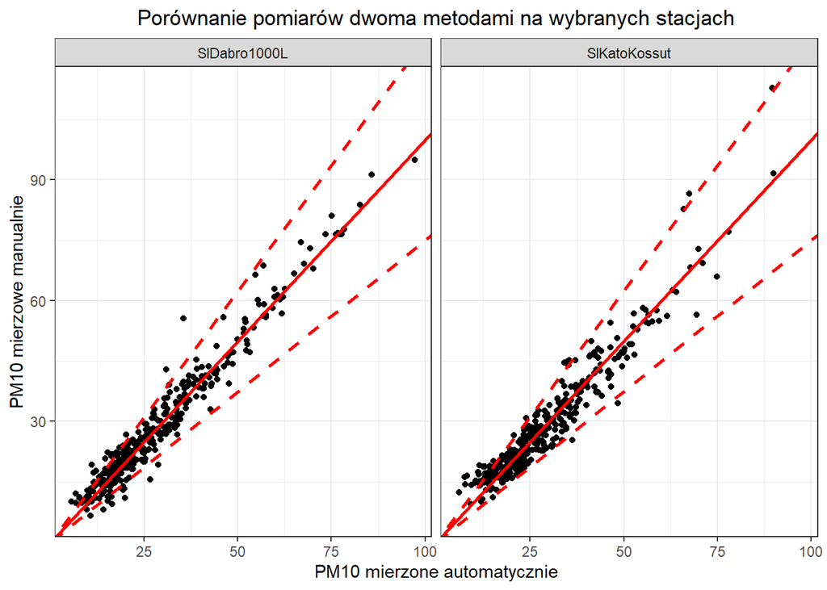

```r
PM10_stacje %>%
  na.omit() %>%
  ggplot(aes(pm10_aut, pm10_man)) +
  geom_point() +
  facet_wrap(~kod) +
  geom_abline(slope = 1,
              color = "red",
              linetype = 1,
              size = 1) +
  geom_abline(slope = 0.75,
              color = "red",
              linetype = 2,
              size = 1) +
  geom_abline(slope = 1.25,
              color = "red",
              linetype = 2,
              size = 1) +
  labs(title = "Porównanie pomiarów dwoma metodami na wybranych stacjach",
       x = "PM10 mierzone automatycznie",
       y = "PM10 mierzowe manualnie") +
  theme_bw() -> p

p + theme(plot.title= element_text(hjust = 0.5))
```

Przedstawione wykresy rozrzutu, prezentują różnicę między pomiarami automatycznymi i manualnymi oraz ich odchylenie od średniej. Wyniki metody automatycznej są poprawne, jednak występują z błędem +- 25%, względem wyników referencyjnych, które są mierzone za pomocą techniki pozwalającej na najwierniejsze odwzorowanie rzeczywistego stanu powietrza.

Porównujemy również róznice w pomiarach, by zobaczyć jak dobrze skalibrowane są pomiary automatyczne.

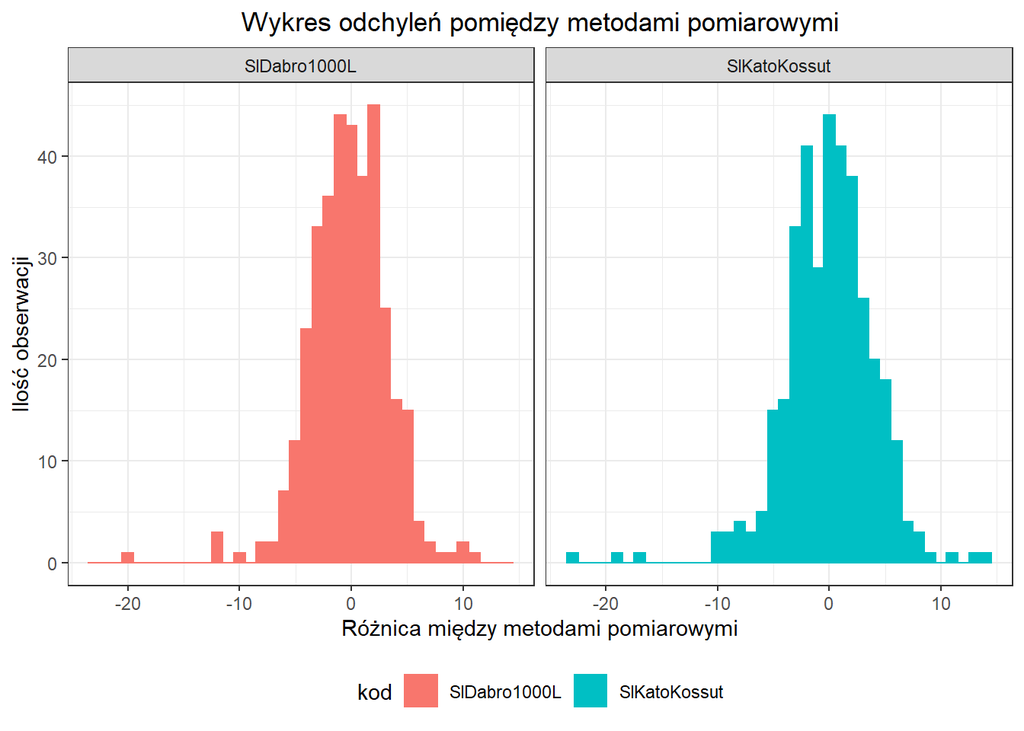

```r
PM10_stacje <- PM10_stacje %>%
  mutate(pm10_diff = pm10_aut - pm10_man)

PM10_stacje %>%
  ggplot(aes(pm10_diff, color = kod, fill = kod)) +
  geom_histogram(binwidth = 1) +
  facet_wrap(~kod) +
  labs(title = "Wykres odchyleń pomiędzy metodami pomiarowymi",
       x = "Różnica między metodami pomiarowymi",
       y = "Ilość obserwacji") +
  theme_bw() -> p

p + theme(legend.position="bottom",
          plot.title = element_text(hjust = 0.5))
```

## 3.2 Funkcja gęstości prawdopodobieństwa

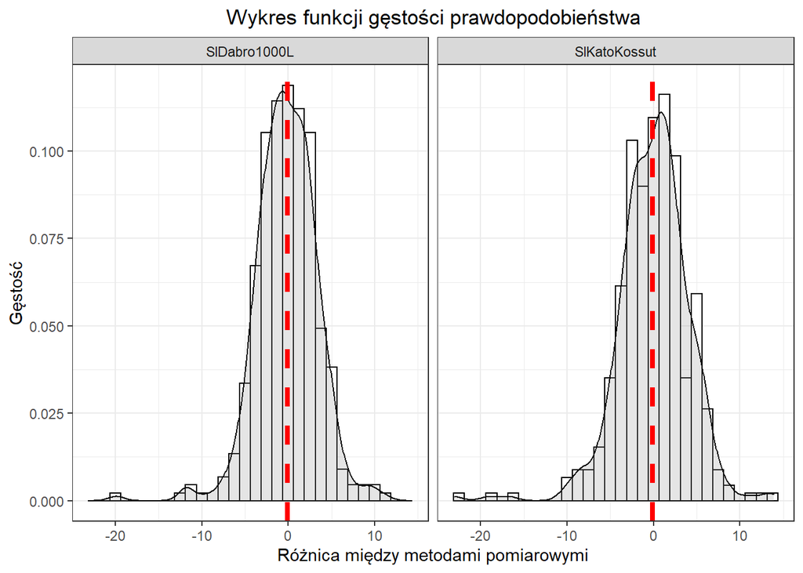

```r
PM10_stacje %>%
  ggplot(aes(x = pm10_diff)) +
  geom_histogram(aes(y = ..density..),
                 binwidth = 1.25,
                 color = "black",
                 fill = "white") +
  geom_density(alpha =0.25, fill = "grey60") +
  geom_vline(aes(xintercept = mean(pm10_diff, na.rm = T,)),
             color = "red",
             size = 1.5,
             linetype = 2) +
  facet_wrap(~kod) +
  labs(title = "Wykres funkcji gęstości prawdopodobieństwa",
         x = "Różnica między metodami pomiarowymi",
         y = "Gęstość") +
  theme_bw() -> p

p + theme(plot.title = element_text(hjust = 0.5))
```

## 3.3 Kompletność danych

Sprawdzamy kompletność danych, najpierw dla stacji w Katowicach

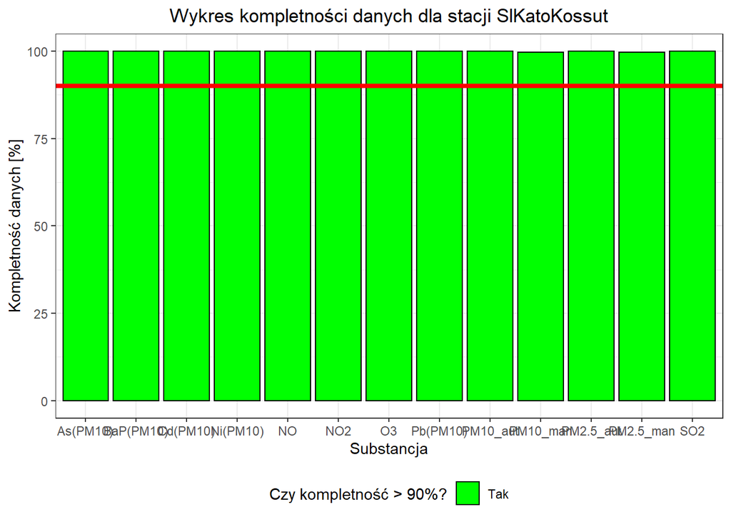

```r
#Kompletność danych
#KATO
g_dane_kato <- dane_kato %>%
  gather(key = sub, value = obs, PM10_aut:'BaP(PM10)') %>%
  group_by(kod, sub) %>%
  summarise(n = n() - sum(is.na(obs)),
            srednia = mean(obs, na.rm = T)) %>%
  filter(n != 0) %>%
  mutate(proc = (n/366)*100) %>%
  arrange(sub, kod)

dane_kato_TF <- g_dane_kato %>% mutate(kompletnosc = if_else(proc >= 90, TRUE, FALSE))

dane_kato_TF %>%
  ggplot(aes(x = sub, y = proc)) +
  geom_bar(stat='identity', aes(fill=kompletnosc), position = 'dodge', color = 'black') +
  scale_fill_manual(values = c("green","red"), labels = c("Tak","Nie")) +
  geom_hline(yintercept = 90, color = 'red', size = 1.5) +
  labs(title = "Wykres kompletności danych dla stacji SlKatoKossut",
       x = "Substancja",
       y = "Kompletność danych [%]",
       fill = "Czy kompletność > 90%?") +
  theme_bw() -> p

p + theme(legend.position="bottom",
          plot.title = element_text(hjust = 0.5))
```

Następnie dla stacji w Dąbrowie Górniczej

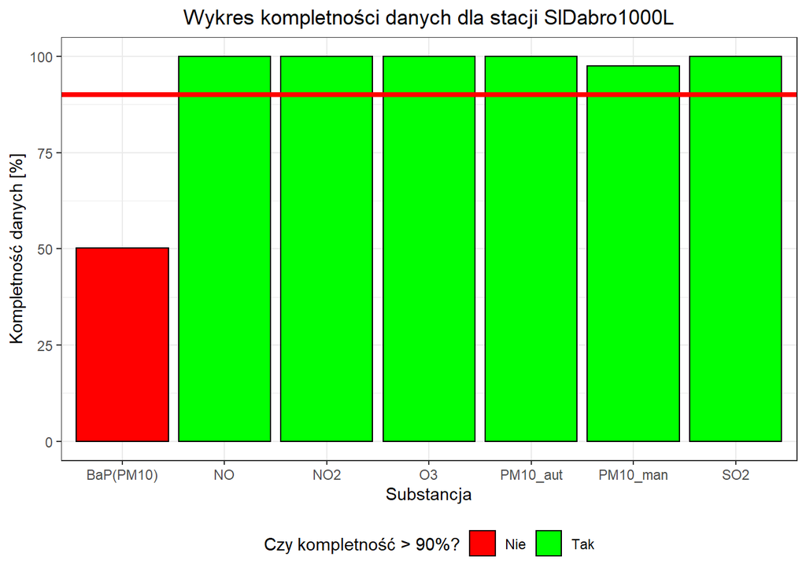

```r
g_dane_dabro <- dane_dabro %>%
  gather(key = sub, value = obs, PM10_aut:'BaP(PM10)') %>%
  group_by(kod, sub) %>%
  summarise(n = n() - sum(is.na(obs)),
            srednia = mean(obs, na.rm = T)) %>%
  filter(n != 0) %>%
  mutate(proc = (n/366)*100) %>%
  arrange(sub, kod)

dane_dabro_TF <- g_dane_dabro %>% mutate(kompletnosc = if_else(proc >= 90, TRUE, FALSE))

dane_dabro_TF %>%
  ggplot(aes(x = sub, y = proc)) +
  geom_bar(stat='identity', aes(fill=kompletnosc), position = 'dodge', color = 'black') +
  scale_fill_manual(values = c("red","green"), labels = c("Nie","Tak")) +
  geom_hline(yintercept = 90, color = 'red', size = 1.5) +
  labs(title = "Wykres kompletności danych dla stacji SlDabro1000L",
       x = "Substancja",
       y = "Kompletność danych [%]",
       fill = "Czy kompletność > 90%?") +
  theme_bw() -> p

p + theme(legend.position="bottom",
          plot.title = element_text(hjust = 0.5))
```

Żeby uzyskać bardziej dokładnie informacje, możemy zastosować polecenie `knitr::kable()`

```r
g_dane_kato %>% knitr::kable()
```

| kod | sub | n | srednia | proc |
| --- | --- | --- | --- | --- |
| SlKatoKossut | As(PM10) | 366 | 1.1217760 | 100.00000 |
| SlKatoKossut | BaP(PM10) | 366 | 3.4858197 | 100.00000 |
| SlKatoKossut | Cd(PM10) | 366 | 0.9995628 | 100.00000 |
| SlKatoKossut | Ni(PM10) | 366 | 1.8857104 | 100.00000 |
| SlKatoKossut | NO | 366 | 8.5475410 | 100.00000 |
| SlKatoKossut | NO2 | 366 | 23.0676776 | 100.00000 |
| SlKatoKossut | O3 | 366 | 41.8389071 | 100.00000 |
| SlKatoKossut | Pb(PM10) | 366 | 0.0166120 | 100.00000 |
| SlKatoKossut | PM10_aut | 366 | 28.7319672 | 100.00000 |
| SlKatoKossut | PM10_man | 365 | 28.7416438 | 99.72678 |
| SlKatoKossut | PM2.5_aut | 366 | 20.1961749 | 100.00000 |
| SlKatoKossut | PM2.5_man | 365 | 20.1895890 | 99.72678 |
| SlKatoKossut | SO2 | 366 | 7.0346175 | 100.00000 |

```r
g_dane_dabro %>% knitr::kable()
```

| kod | sub | n | srednia | proc |
| --- | --- | --- | --- | --- |
| SlDabro1000L | BaP(PM10) | 184 | 4.031630 | 50.27322 |
| SlDabro1000L | NO | 366 | 9.057158 | 100.00000 |
| SlDabro1000L | NO2 | 366 | 21.823388 | 100.00000 |
| SlDabro1000L | O3 | 366 | 42.161066 | 100.00000 |
| SlDabro1000L | PM10_aut | 366 | 28.744262 | 100.00000 |
| SlDabro1000L | PM10_man | 357 | 29.005322 | 97.54098 |
| SlDabro1000L | SO2 | 366 | 6.374044 | 100.00000 |

Kompletność danych, wszystkich zmierzonych przez stację w Katowicach, jest na poziomie powyżej 99% co pozwala nam na wiarygodne przeanalizowanie jakości powietrza. Natomiast kompletność danych, zmierzonych przez stację w Dąbrowie Górniczej jest również na bardzo wysokim poziomie. Jedynie kompletność danych o Benzo(a)pirenie, zawartym w PM10, nie pozwala nam na wiarygodne przeanalizowanie tej substancji.

## 3.4 Stężenia poszczególnych substancji

Zbadajmy teraz poziomy poszczególnych substancji dla wybranych przez nas stacji w celu sprawdzenia, czy ich zawartość w powietrzu spełnia normy prawne. Jeśli średnia roczna substancji przechodzi przez czerwoną linię, oznacza to, że wykracza ona poza normę.

### 3.4.1 Stacja w Katowicach

#### 3.4.1.1 As(PM10)

Docelowy poziom Arsenu w powietrzu, ze względu na ochronę zdrowia ludzi, nie może przekraczać $6 ng/m^{3}$

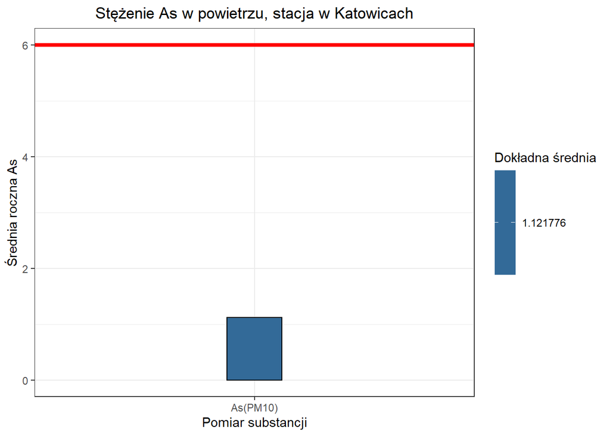

```r
#poziomy substancji:
#KATO

#As(PM10): 6
dane_kato_As <- g_dane_kato %>% filter(sub == "As(PM10)")

dane_kato_As %>%
  ggplot(aes(x = sub, y = srednia)) +
  geom_bar(stat='identity', aes(fill=srednia),color = 'black', width = 0.15) +
  geom_hline(yintercept = 6, color = 'red', size = 1.5) +
  labs(title = "Stężenie As w powietrzu, stacja w Katowicach",
       x = "Pomiar substancji",
       y = "Średnia roczna As",
       fill = "Dokładna średnia") +
  theme_bw() -> p

p + theme(plot.title = element_text(hjust = 0.5))
```

Jak możemy zaobserwować, poziom Arsenu w pyle zawieszonym PM10 na stacji w Katowicach ledwo przekracza $1 ng/m^{3}$, przez co możemy powiedzieć, że jego stężenie jest naprawdę bardzo niskie.

#### 3.4.1.2 BaP(PM10)

Docelowy poziom Benzo(a)pirenu w powietrzu nie może przekraczać $1 ng/m^{3}$

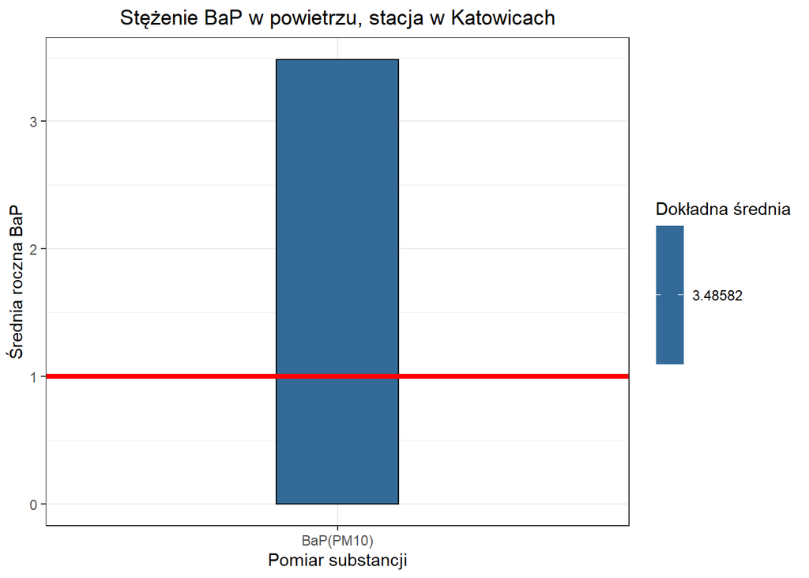

```r
#BaP(PM10): 1
dane_kato_BaP <- g_dane_kato %>% filter(sub == "BaP(PM10)")

dane_kato_BaP %>%
  ggplot(aes(x = sub, y = srednia)) +
  geom_bar(stat='identity', aes(fill=srednia),color = 'black', width = 0.25) +
  geom_hline(yintercept = 1, color = 'red', size = 1.5) +
  labs(title = "Stężenie BaP w powietrzu, stacja w Katowicach",
       x = "Pomiar substancji",
       y = "Średnia roczna BaP",
       fill = "Dokładna średnia") +
  theme_bw() -> p

p + theme(plot.title = element_text(hjust = 0.5))
```

Benzo(a)piren jest jednym z najbardziej toksycznych składników smogu. Gromadzi się w organizmie i może powodować raka, upośledzać płodność i działać szkodliwie na dziecko w łonie matki. Jak widać na powyższym wykresie, roczna średnia stężenia tej substancji w powietrzu mierzonym na stacji w Katowicach ponad 3-krotnie przekracza dopuszczalną normę.

#### 3.4.1.3 Cd(PM10)

Maksymalne dopuszczalne stężenie kadmu w PM10 wynosi $5 ng/m^{3}$

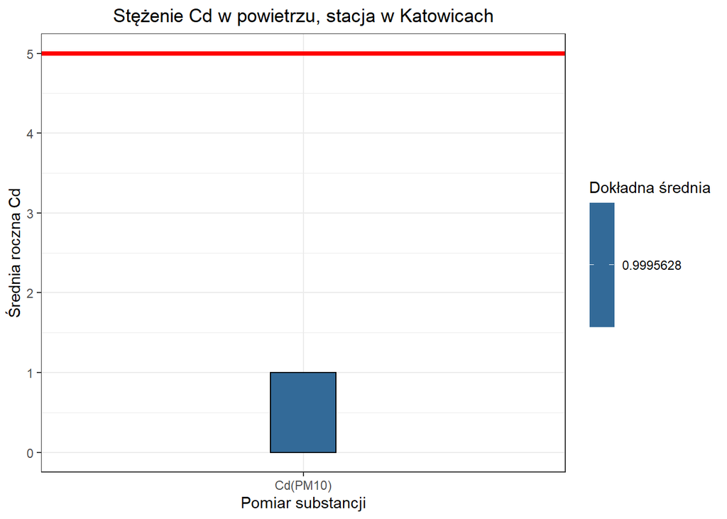

```r
#Cd(PM10):5
dane_kato_Cd <- g_dane_kato %>% filter(sub == "Cd(PM10)")

dane_kato_Cd %>%
  ggplot(aes(x = sub, y = srednia)) +
  geom_bar(stat='identity', aes(fill=srednia),color = 'black', width = 0.15) +
  geom_hline(yintercept = 5, color = 'red', size = 1.5) +
  labs(title = "Stężenie Cd w powietrzu, stacja w Katowicach",
       x = "Pomiar substancji",
       y = "Średnia roczna Cd",
       fill = "Dokładna średnia") +
  theme_bw() -> p

p + theme(plot.title = element_text(hjust = 0.5))
```

Jak widać, w powietrzu blisko tej stacji stężenie kadmu jest naprawdę bardzo małe.

#### 3.4.1.4 Ni(PM10)

Stężenie Niklu nie może przekraczać $20 ng/m^{3}$

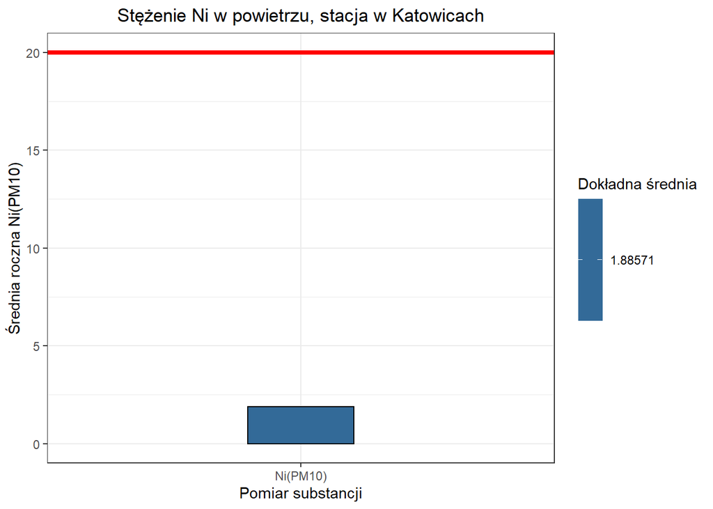

```r
#Ni(PM10) 20:
dane_kato_Ni <- g_dane_kato %>% filter(sub == "Ni(PM10)")

dane_kato_Ni %>%
  ggplot(aes(x = sub, y = srednia)) +
  geom_bar(stat='identity', aes(fill=srednia),color = 'black', width = 0.25) +
  geom_hline(yintercept = 20, color = 'red', size = 1.5) +
  labs(title = "Stężenie Ni w powietrzu, stacja w Katowicach",
       x = "Pomiar substancji",
       y = "Średnia roczna Ni(PM10)",
       fill = "Dokładna średnia") +
  theme_bw() -> p

p + theme(plot.title = element_text(hjust = 0.5))
```

Z wykresu możemy odczytać, że tutaj stężenie Niklu jest naprawdę znikome. Nie przekracza ono $2 ng/m^{3}$, czyli nie dochodzi nawet do 1/10 normy.

#### 3.4.1.5 Pb(PM10)

Zgodnie z ustaloną normą prawną, dopuszczalny poziom zawartości ołowiu w powietrzu wynosi $0,5 [µg/m^{3}]$

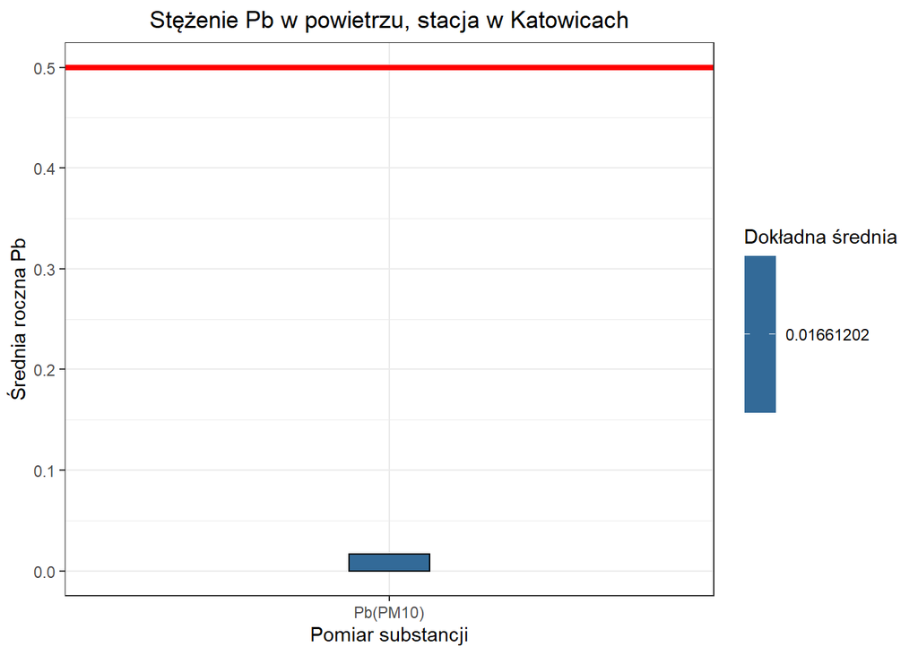

```r
#Pb(PM10): 0,5
dane_kato_Pb <- g_dane_kato %>% filter(sub == "Pb(PM10)")

dane_kato_Pb %>%
  ggplot(aes(x = sub, y = srednia)) +
  geom_bar(stat='identity', aes(fill=srednia),color = 'black', width = 0.15) +
  geom_hline(yintercept = 0.5, color = 'red', size = 1.5) +
  labs(title = "Stężenie Pb w powietrzu, stacja w Katowicach",
       x = "Pomiar substancji",
       y = "Średnia roczna Pb",
       fill = "Dokładna średnia") +
  theme_bw() -> p

p + theme(plot.title = element_text(hjust = 0.5))
```

Na wybranej przez nas stacji poziom ołowiu nie przekracza normy, jest bardzo niski.

#### 3.4.1.6 NO

Docelowy poziom Tlenku azotu w powietrzu nie może przekraczać $30 [µg/m^{3}]$

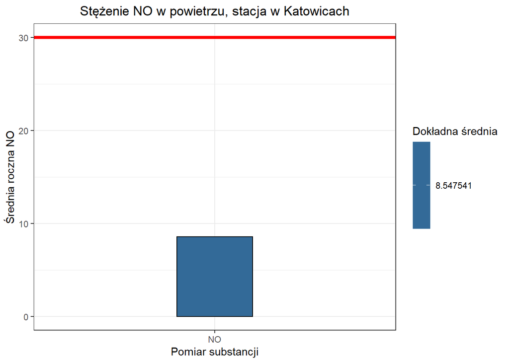

```r
#NO: 30
dane_kato_NO <- g_dane_kato %>% filter(sub == "NO")

dane_kato_NO %>%
  ggplot(aes(x = sub, y = srednia)) +
  geom_bar(stat='identity', aes(fill=srednia),color = 'black', width = 0.25) +
  geom_hline(yintercept = 30, color = 'red', size = 1.5) +
  labs(title = "Stężenie NO w powietrzu, stacja w Katowicach",
       x = "Pomiar substancji",
       y = "Średnia roczna NO",
       fill = "Dokładna średnia") +
  theme_bw() -> p

p + theme(plot.title = element_text(hjust = 0.5))
```

Widzimy, że poziom tej substancji w powietrzu nie przekracza przyjętej normy.

#### 3.4.1.7 NO2

Stężenie Dwutlenku azotu nie może przekraczać $40 [µg/m^{3}]$

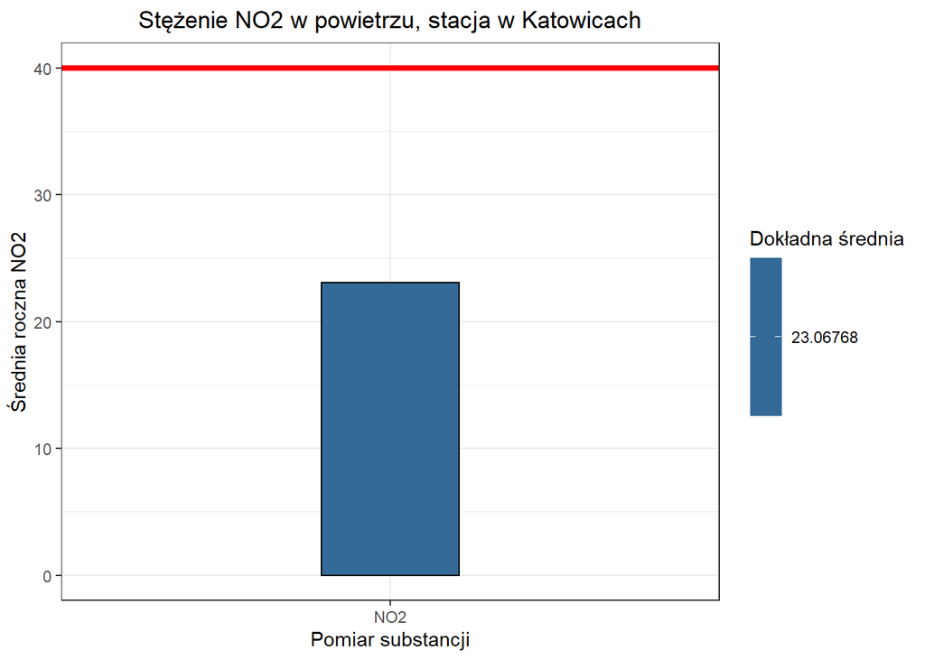

```r
#NO2: 40
dane_kato_NO2 <- g_dane_kato %>% filter(sub == "NO2")

dane_kato_NO2 %>%
  ggplot(aes(x = sub, y = srednia)) +
  geom_bar(stat='identity', aes(fill=srednia),color = 'black', width = 0.25) +
  geom_hline(yintercept = 40, color = 'red', size = 1.5) +
  labs(title = "Stężenie NO2 w powietrzu, stacja w Katowicach",
       x = "Pomiar substancji",
       y = "Średnia roczna NO2",
       fill = "Dokładna średnia") +
  theme_bw() -> p

p + theme(plot.title = element_text(hjust = 0.5))
```

Z wykresu odczytujemy, że roczne średnie stężenie tej substancji w powietrzu nie przekracza normy prawnej.

#### 3.4.1.8 PM10 (automatyczne)

Pył zawieszony PM10 odpowiada za ataki kaszlu, świszczący oddech, pogorszenie się stanu osób z astmą czy za ostre, gwałtowne zapalenie oskrzeli. W sposób pośredni PM10 wpływa również negatywnie na resztę organizmu, między innymi zwiększając ryzyko zawału serca oraz wystąpienia udaru mózgu. Maksymalne dopuszczalne średnioroczne stężenie pyłu zawieszonego PM10 w powietrzu, zgodnie z przyjętą normą prawną nie może przekraczać $40 [µg/m^{3}]$. Zobaczmy, jak wygląda sytuacja na stacji w Katowicach

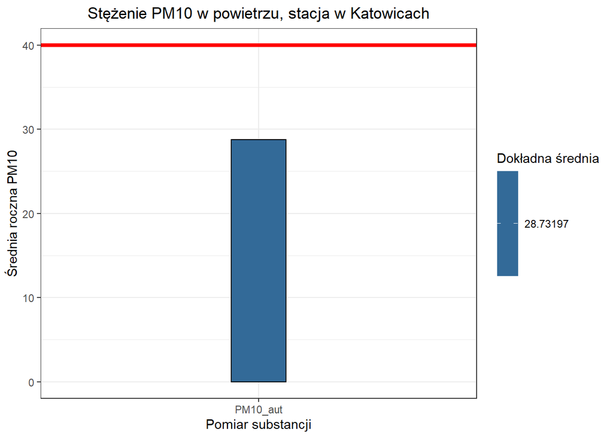

```r
#PM10_aut:
dane_kato_PM10 <- g_dane_kato %>% filter(sub == "PM10_aut")

dane_kato_PM10 %>%
  ggplot(aes(x = sub, y = srednia)) +
  geom_bar(stat='identity', aes(fill=srednia),color = 'black', width = 0.15) +
  geom_hline(yintercept = 40, color = 'red', size = 1.5) +
  labs(title = "Stężenie PM10 w powietrzu, stacja w Katowicach",
       x = "Pomiar substancji",
       y = "Średnia roczna PM10",
       fill = "Dokładna średnia") +
  theme_bw() -> p

p + theme(plot.title = element_text(hjust = 0.5))
```

Jak możemy zaobserwować na wykresie, na tej stacji stężenie PM10 jest w normie.

#### 3.4.1.9 PM2.5 (automatyczne)

PM2.5 to aerozole atmosferyczne, których średnica nie jest większa niż 2.5 mikrometra. Tego rodzaju pył zawieszony jest uznawany za najgroźniejszy dla zdrowia człowieka. Wszystko dlatego, że pył jest bardzo drobny, a w takiej postaci może się przedostać bezpośrednio do krwiobiegu. To właśnie ten rodzaj pyłu zawieszonego jest odpowiedzialny za m.in.: nowotwory płuc, gardła i krtani. Normy dopuszczają maksymalne średnioroczne stężenie pyłu PM2.5 na poziomie nie wyższym, niż $25 [µg/m^{3}]$.

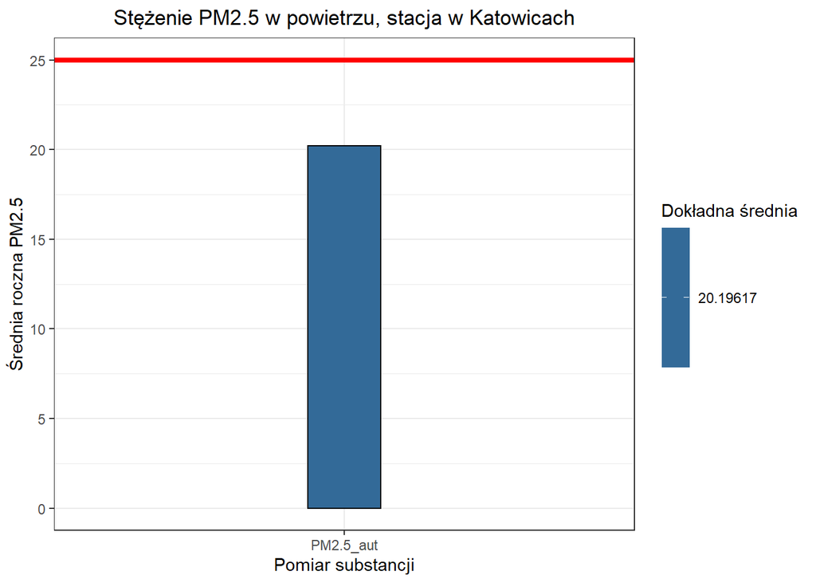

```r
#PM2.5_aut:
dane_kato_PM2.5 <- g_dane_kato %>% filter(sub == "PM2.5_aut")

dane_kato_PM2.5 %>%
  ggplot(aes(x = sub, y = srednia)) +
  geom_bar(stat='identity', aes(fill=srednia),color = 'black', width = 0.15) +
  geom_hline(yintercept = 25, color = 'red', size = 1.5) +
  labs(title = "Stężenie PM2.5 w powietrzu, stacja w Katowicach",
       x = "Pomiar substancji",
       y = "Średnia roczna PM2.5",
       fill = "Dokładna średnia") +
  theme_bw() -> p

p + theme(plot.title = element_text(hjust = 0.5))
```

Jak możemy zauwazyć, stężenie PM2.5 na stacji w Katowicach jest dosyć wysokie, jednak wciąż mieści się w granicach normy.

#### 3.4.1.10 Wszystkie substancje

Zobaczmy również średnioroczne stężenia wszystkich substancji, których poziom w powietrzu mierzy stacja `SlKatoKossut`.

```r
g_dane_kato %>% knitr::kable()
```

| kod | sub | n | srednia | proc |
| --- | --- | --- | --- | --- |
| SlKatoKossut | As(PM10) | 366 | 1.1217760 | 100.00000 |
| SlKatoKossut | BaP(PM10) | 366 | 3.4858197 | 100.00000 |
| SlKatoKossut | Cd(PM10) | 366 | 0.9995628 | 100.00000 |
| SlKatoKossut | Ni(PM10) | 366 | 1.8857104 | 100.00000 |
| SlKatoKossut | NO | 366 | 8.5475410 | 100.00000 |
| SlKatoKossut | NO2 | 366 | 23.0676776 | 100.00000 |
| SlKatoKossut | O3 | 366 | 41.8389071 | 100.00000 |
| SlKatoKossut | Pb(PM10) | 366 | 0.0166120 | 100.00000 |
| SlKatoKossut | PM10_aut | 366 | 28.7319672 | 100.00000 |
| SlKatoKossut | PM10_man | 365 | 28.7416438 | 99.72678 |
| SlKatoKossut | PM2.5_aut | 366 | 20.1961749 | 100.00000 |
| SlKatoKossut | PM2.5_man | 365 | 20.1895890 | 99.72678 |
| SlKatoKossut | SO2 | 366 | 7.0346175 | 100.00000 |

### 3.4.2 Stacja w Dąbrowie Górniczej

#### 3.4.2.1 NO

Spójrzmy również na stężenie tlenku azotu na stacji w Dąbrowie Górniczej

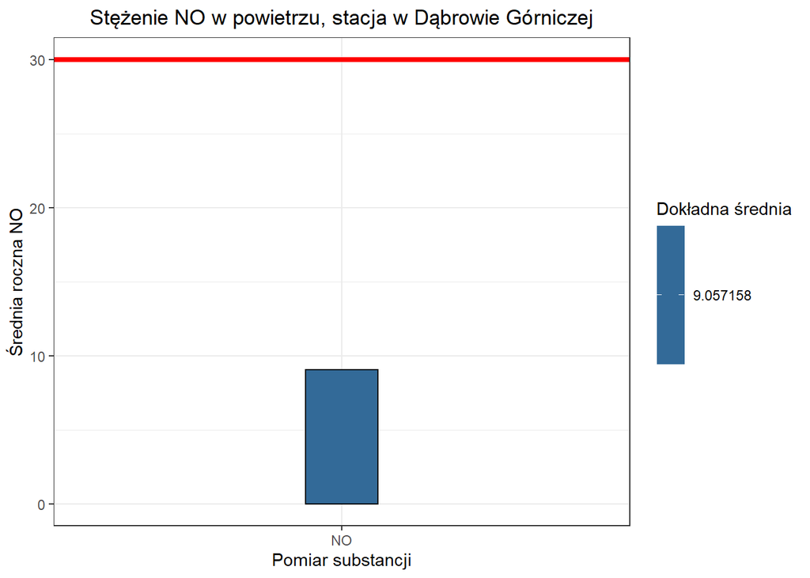

```r
#DABRO
#NO:
dane_dabro_NO <- g_dane_dabro %>% filter(sub == "NO")

dane_dabro_NO %>%
  ggplot(aes(x = sub, y = srednia)) +
  geom_bar(stat='identity', aes(fill=srednia),color = 'black', width = 0.15) +
  geom_hline(yintercept = 30, color = 'red', size = 1.5) +
  labs(title = "Stężenie NO w powietrzu, stacja w Dąbrowie Górniczej",
       x = "Pomiar substancji",
       y = "Średnia roczna NO",
       fill = "Dokładna średnia") +
  theme_bw() -> p

p + theme(plot.title = element_text(hjust = 0.5))
```

Podobnie jak w przypadku stacji `SlKatoKossut`, tak i tutaj średnioroczne stężenie tlenku azotu, nie przekracza normy - jest stosunkowo niskie.

#### 3.4.2.2 NO2

Sprawdżmy jak ma się sytuacja, jeśli chodzi o dwutlenek azotu na stacji `SlDabro1000L`

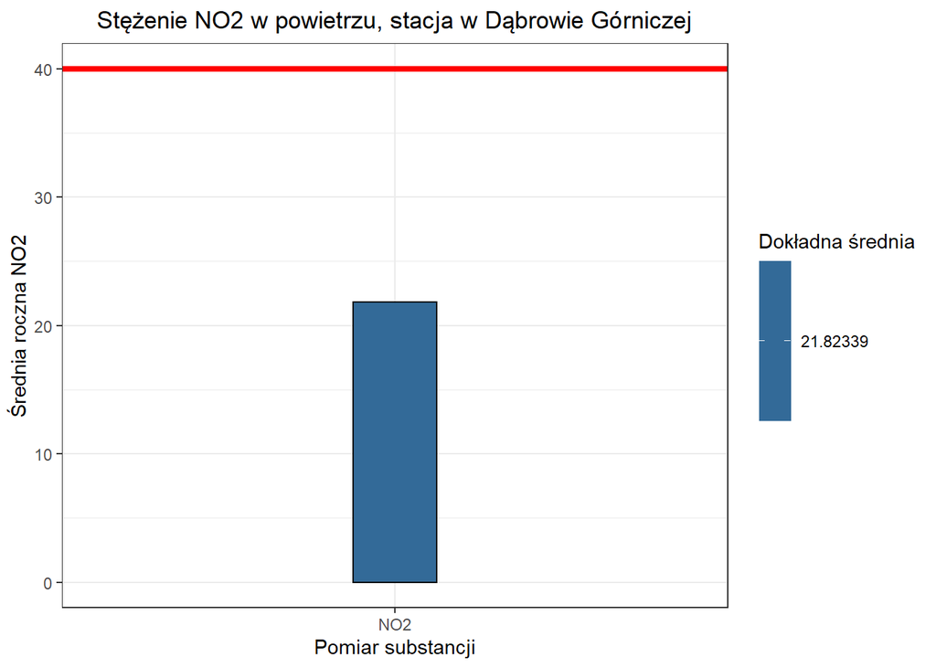

```r
#NO2:
dane_dabro_NO2 <- g_dane_dabro %>% filter(sub == "NO2")

dane_dabro_NO2 %>%
  ggplot(aes(x = sub, y = srednia)) +
  geom_bar(stat='identity', aes(fill=srednia),color = 'black', width = 0.15) +
  geom_hline(yintercept = 40, color = 'red', size = 1.5) +
  labs(title = "Stężenie NO2 w powietrzu, stacja w Dąbrowie Górniczej",
       x = "Pomiar substancji",
       y = "Średnia roczna NO2",
       fill = "Dokładna średnia") +
  theme_bw() -> p

p + theme(plot.title = element_text(hjust = 0.5))
```

Jak widzimy na wykresie, stężenie tej substancji również nie przekracza wyznaczonej normy.

#### 3.4.2.3 PM10 (automatyczne)

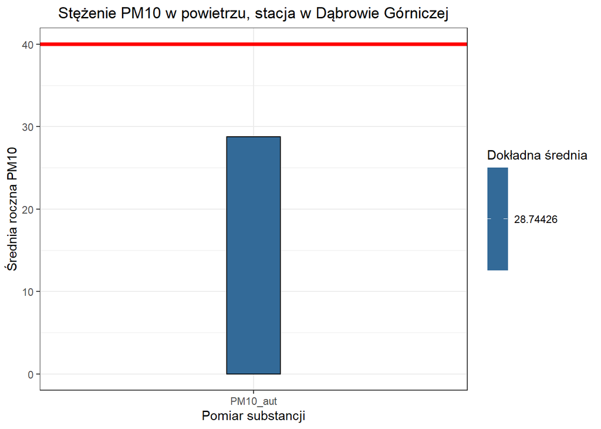

```r
#PM10_aut:
dane_dabro_PM10 <- g_dane_dabro %>% filter(sub == "PM10_aut")

dane_dabro_PM10 %>%
  ggplot(aes(x = sub, y = srednia)) +
  geom_bar(stat='identity', aes(fill=srednia),color = 'black', width = 0.15) +
  geom_hline(yintercept = 40, color = 'red', size = 1.5) +
  labs(title = "Stężenie PM10 w powietrzu, stacja w Dąbrowie Górniczej",
       x = "Pomiar substancji",
       y = "Średnia roczna PM10",
       fill = "Dokładna średnia") +
  theme_bw() -> p

p + theme(plot.title = element_text(hjust = 0.5))
```

Na tej stacji stężenie pyłu PM10 jest praktycznie takie samo, jak na stacji w Katowicach.

#### 3.4.2.4 Wszystkie substancje

Podejrzyjmy średnie stężenia substancji na stacji `SlDabro1000L` za pomocą funkcji `kable()` z pakietu `knitr`.

```r
g_dane_dabro %>% knitr::kable()
```

| kod | sub | n | srednia | proc |
| --- | --- | --- | --- | --- |
| SlDabro1000L | BaP(PM10) | 184 | 4.031630 | 50.27322 |
| SlDabro1000L | NO | 366 | 9.057158 | 100.00000 |
| SlDabro1000L | NO2 | 366 | 21.823388 | 100.00000 |
| SlDabro1000L | O3 | 366 | 42.161066 | 100.00000 |
| SlDabro1000L | PM10_aut | 366 | 28.744262 | 100.00000 |
| SlDabro1000L | PM10_man | 357 | 29.005322 | 97.54098 |
| SlDabro1000L | SO2 | 366 | 6.374044 | 100.00000 |

## 3.5 Ilość przekroczeń normy

W rozporządzeniu Ministra Klimatu i Środowiska w sprawie dokonywania oceny poziomów substancji w powietrzu opisane zostały również kwestie, dotyczące dopuszczalnej częstości przekroczeń maksymalnego stężenia danej substancji w roku kalendarzowym. Przykładowo, dla pyłu zawieszonego `PM10` dopuszcza się przekroczenie normy maksymalnie 35 razy w ciągu całego roku.

Zbadajmy zatem, ile razy niektóre substancje zawarte w powietrzu mierzonym na wybranych przez nas stacjach przekraczają w ciągu roku normy.

### 3.5.1 Katowice

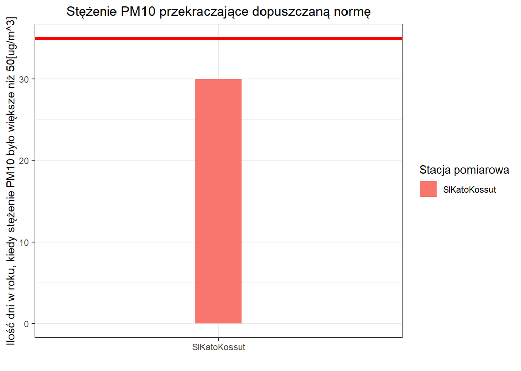

```r
#PM10
p_kato_PM10 <- dane_kato %>% mutate(przekroczenie = if_else(PM10_aut > 50,1,0))
p_kato_PM10 <- p_kato_PM10 %>% filter(przekroczenie == 1)
p_kato_PM10 <- p_kato_PM10 %>% mutate(sum_przekroczenie = sum(p_kato_PM10$przekroczenie))

p_kato_PM10 %>%
  ggplot(aes(x = kod, y = sum_przekroczenie)) +
  geom_bar(stat='identity',aes(fill = kod ), position="dodge", width = 0.15, ) +
  geom_hline(yintercept = 35, color = 'red', size = 1.5) +
  labs(title = "Stężenie PM10 przekraczające dopuszczaną normę",
       x = " ",
       y = "Ilość dni w roku, kiedy stężenie PM10 było większe niż 50[ug/m^3]",
       fill = "Stacja pomiarowa") +
  theme_bw() -> p

p + theme(plot.title = element_text(hjust = 0.5))
```

Jak możemy zaobserwować, na stacji w Katowicach ilość przekroczeń normy dla PM10 w ciągu roku nie przekracza maksymalnej wartości określonej w ustawie.

Z kolei, zarówno normy dla NO2 i SO2 nie zostały przekroczone ani razu.

```r
#NO2
p_kato_NO2 <- no2_1h_2020_Kato %>% mutate(przekroczenie = if_else(obs > 200,1,0))
sum(p_kato_NO2$przekroczenie, na.rm = T)
```

```
## [1] 0
```

```r
#SO2
p_kato_SO2 <- so2_24h_2020_Kato %>% mutate(przekroczenie = if_else(obs > 125,1,0))
sum(p_kato_SO2$przekroczenie, na.rm = T)
```

```
## [1] 0
```

### 3.5.2 Dąbrowa Górnicza

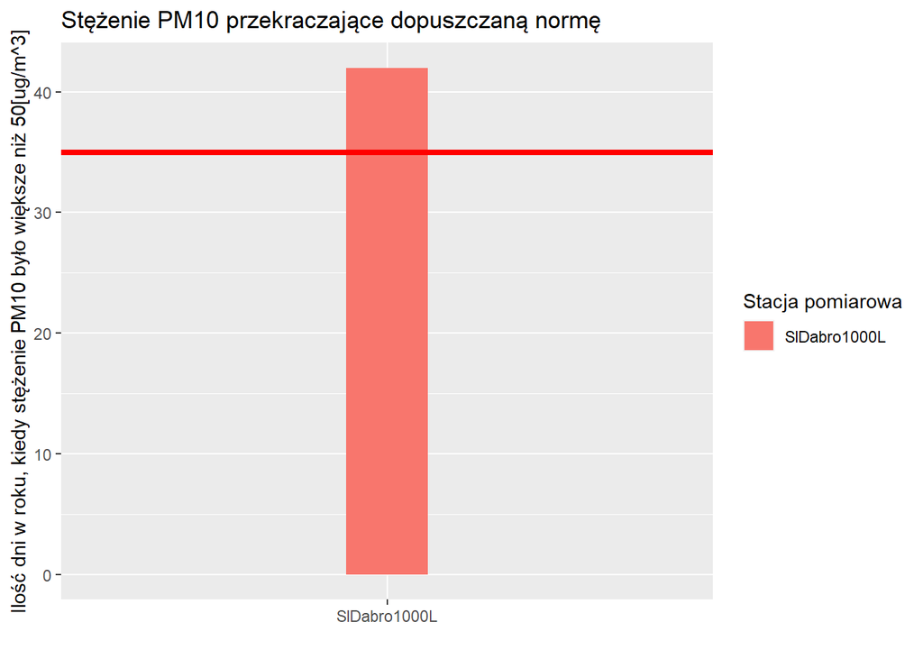

```r
#PM10
p_dabroPM10 <- aut_pm10_24h_2020_Dabro %>% mutate(przekroczenie = if_else(obs > 50,1,0))
p_dabroPM10 <- p_dabroPM10 %>% mutate(sum_przekroczenie = sum(p_dabroPM10$przekroczenie))

p_dabroPM10 %>%
  ggplot(aes(x = kod, y = sum_przekroczenie)) +
  geom_bar(stat='identity',aes(fill = kod ), position="dodge", width = 0.15, ) +
  geom_hline(yintercept = 35, color = 'red', size = 1.5) +
  labs(title = "Stężenie PM10 przekraczające dopuszczaną normę",
       x = " ",
       y = "Ilość dni w roku, kiedy stężenie PM10 było większe niż 50[ug/m^3]",
       fill = "Stacja pomiarowa")
```

Jak widzimy, niestety, powietrze w okolicy stacji w Dąbrowie Górniczej jest bardziej zanieczyszczone, w stosunku do powietrza badanego na drugiej stacji. W tym przypadku ilość przekroczeń dopuszczalnej zawartości pyłu PM10 w powietrzu w ciągu roku przewyższa maksymalną ilość opisaną w ustawie.

Jednakże, w przypadku SO2 i NO2 sytuacja jest podobna, jak w przypadku stacji w Katowicach - w ciągu roku nie wystąpiły tutaj żadne przekroczenia normy.

```r
#NO2
p_dabro_NO2 <- no2_1h_2020_Dabro %>% mutate(przekroczenie = if_else(obs > 200,1,0))
sum(p_dabro_NO2$przekroczenie, na.rm = T)
```

```
## [1] 0
```

```r
#SO2
p_dabro_SO2 <- so2_24h_2020_Dabro %>% mutate(przekroczenie = if_else(obs > 125,1,0))
sum(p_dabro_SO2$przekroczenie, na.rm = T)
```

```
## [1] 0
```

# 4. Wnioski

## 4.1 Analiza jakości powietrza

Poziom pyłu zawieszonego PM2.5 mierzony na stacji w Katowicach, chociaż osiąga wysoki poziom w skali roku, to wciąż mieści się w normie. Niestety, na stacji w Dąbrowie Górniczej nie wykonuje się pomiaru tego pyłu.

Normy dla dwutlenku siarki oraz dwutlenku azotu nie zostały przekroczone ani razu, na żadnej ze stacji. Ich średnioroczne stężenia utrzymują się na dobrym poziomie. Podobnie jest w przypadku pozostałych substancji - większość z nich nie przekracza ustalonej normy.

Wyjątkiem tutaj jest Benzo(a)piren zawarty w pyle PM10 - na stacji w Katowicach, przekracza on znacząco, bo aż ponad 3-krotnie dopuszczalną normę. BaP należy do substancji emitowanych przez rury samochodowe, papierosy, a przede wszystkim piece i kotły. Wydziela się podczas spalania węgla (zwłaszcza tego złej jakości), drewna i śmieci (zwłaszcza tworzyw sztucznych typu PET). W celu ograniczenia wydzielania tej rakotwórczej substancji, można np.: wymienić piec na bardziej nowoczesny.

Podsumowując: z analizy wykonanej na uzyskanych danych można wywnioskować, że jakość powietrza w Katowicach oraz w Dąbrowie górniczej jest wystarczająco dobra. Uzyskane wyniki w większości nie przekraczają norm ustanowionych rozporządzeniem.

## 4.2 Metoda automatyczna vs manualna

Metoda referencyjna (manualna) jest uważana za najbardziej precyzyjną metodę pomiaru. Analiza wskazuje na to, że metoda automatyczna jest równoważna do metody manualnej.

Zaletą metody referencyjnej jest jej bardzo wysoka dokładność, ale długi czas potrzebny do uzyskania wyników to niewątpliwie duży minus. Dużą przewagą metody automatycznej jest aktualizacja danych co godzinę.